# LiDAR API

## Goal

We seek to find areas where LiDAR data has been collected on two occasions. Eventually, we will use fire perimeter data to find areas where LiDAR was collected before and after a fire. That might allow us some insight into the effects of fire on the properties of vegetation and particularly underbrush, potentially using the machine-learning approach that Tony proposed.

## Approach

I plan to use the R packages in the [tidyverse](https://www.tidyverse.org) to process LiDAR data taken from the [web API](https://apps.nationalmap.gov/tnmaccess/#/) provided by [The National Map](https://apps.nationalmap.gov/lidar-explorer/#/). Ultimately, interacting with URLs is performed using a package that ports [curl](https://curl.se/) over to R. I’ll also use [sf](https://r-spatial.github.io/sf/#cheatsheet) for spatial analysis. I’ll leave in the package messages and metadata just in case they help down the road.

```r
knitr::opts_chunk$set(fig.width=12, fig.height=8, fig.align = "center")

# Load R packages
library(tidyverse)
library(curl)
library(sf)
```

## Finding a dataset

Initially, I used the dataset API but it was not especially helpful. It only has 15 items. Well, anyways, I’ve been playing around on the user-friendly [API for data products](https://apps.nationalmap.gov/tnmaccess/#/product) and have learned how to target LiDAR products using URL queries that way, so let’s move on to that.

## Finding LiDAR data

To begin moving towards a sensible dataset size, let’s restrict our search to the continental US (CONUS). Not that it helps all that much, seeing as there are still over 6 million products. A bounding box for the CONUS spans roughly 60 degrees of longitude (125° W to 65° W) and 30 degrees of latitude (20° N to 50° N), including a little bit of cushion.

Let’s get our hands dirty. I’m going to pick a random 1°×1° box somewhere in the Western US and query all the LiDAR data it contains.

```r
ptm <- proc.time() # A timer will help assess the feasibility of upscaling

# Describe URL components for the query
root_url <- "https://tnmaccess.nationalmap.gov/api/v1/products?"
bbox_url <- "bbox=-100,40,-99,41"
type_url <- "datasets=Lidar%20Point%20Cloud%20(LPC)"
maxn_url <- "max=10000"
form_url <- "outputFormat=CSV"

# Open a connection to the server using the query
url <- url(paste0(root_url,bbox_url,"&",type_url,"&",maxn_url,"&",form_url))

# Download the data from the server
data <- read_csv(url)
proc.time() - ptm # Calculate duration
```

```
##    user  system elapsed
##    0.11    0.00    6.50
```

The API guide said that it was possible to get 10,000 results per page, but it appears that the limit is actually 1,000. Oh well.

```r
maxn_url_fixed <- "max=1000"

offset <- 100 # Start with the 101st item
offset_url <- paste0("offset=",offset)

# Update the query
url <- url(paste0(root_url,bbox_url,"&",type_url,"&",maxn_url_fixed,"&",offset_url,"&",form_url))

# Download data using the new query
data_check <- read_csv(url)
# Check how many items are shared in common between the two
length(intersect(data$downloadURL, data_check$downloadURL)) # URLs are unique identifiers
```

```
## [1] 900
```

As we’d expect, skipping 100 entries leaves 900 entries in common. Now let’s see if we can get all the data from our 1°×1° box into one table.

```r
# Specify our page size explicitly
max_n <- 1000

# Also specify a break point for our loop for safety
break_n <- 2e4 # i.e., 10,000

# Reset the offset
offset <- 0
offset_url <- paste0("offset=",offset)

ptm <- proc.time() # Start the timer

# Update the query
url <- url(paste0(root_url,bbox_url,"&",type_url,"&",maxn_url_fixed,"&",offset_url,"&",form_url))

# Download the data
new_data <- read_csv(url)
# Create a copy to compile data from multiple queries
data_all <- new_data

# Query the server repeatedly until either a partial page of results is returned or the break point is reached
suppressMessages({ # Remove repeated, identical messages
    while (nrow(new_data) == max_n & nrow(data_all) <= break_n) {
        offset <- offset + max_n
        offset_url <- paste0("offset=",offset)
        url <- url(paste0(root_url,bbox_url,"&",type_url,"&",maxn_url_fixed,"&",offset_url,"&",form_url))
        new_data <- read_csv(url)
        data_all <- bind_rows(data_all, new_data)
    }
})

proc.time() - ptm # This could be inaccurate because repeating a query yields results much faster
```

```
##    user  system elapsed
##    0.41    0.04   44.10
```

```r
nrow(data_all) == length(unique(data_all$downloadURL)) # Check whether all results are unique
```

```
## [1] TRUE
```

```r
nrow(data_all) # Total number of products in the box
```

```
## [1] 10314
```

On the first go, getting 10,000 results took about 45 seconds. Round up to a minute and that suggests we could populate a table with all 7 million results in less than 12 hours if we wanted to, assuming that the TNM API doesn’t use DDoS-prevention technology.

## Assessing overlap of LiDAR data

Let’s see how often the data in our little box overlap. If overlap is limited, maybe we’ll need to zoom out to a bigger box.

```r
# Extract minimum and maximum latitude and longitude from the boundingBox variable
bboxes <- data_all %>%
    select(downloadURL, publicationDate, box = boundingBox) %>% # Collection date does not appear to be available
    separate(box, sep = "min|max", into = c(NA, "xmin", "xmax", "ymin", "ymax")) %>% # Split bounding-box column
    mutate(across(xmin:ymax, ~str_extract(.x, "-?[0-9]+.[0-9]+"))) %>% # Extract numbers
    mutate(across(xmin:ymax, as.numeric)) # Convert to numeric type

# Assess total area covered by LiDAR data
bboxes %>%
    mutate(area = (xmax - xmin)*(ymax - ymin)) %>%
    summarise(sum(area))
```

```
## # A tibble: 1 × 1
##   `sum(area)`
##         <dbl>
## 1        2.08
```

That is promising. Our random box has an area of 1° squared, but contains about 2° squared worth of LiDAR data. Granted, these are bounding boxes so coverage is not guaranteed, but most LiDAR products from The National Map are rectangular, at least in my experience.

```r
# Convert the bounding boxes to a spatial object
bbox_layer <- bboxes %>%
    pivot_longer(c(xmin, xmax), names_to = "x", values_to = "lon") %>% # This and the next command
    pivot_longer(c(ymin, ymax), names_to = "y", values_to = "lat") %>% # create rows for each corner
    group_by(downloadURL, publicationDate) %>%
    # Create convex polygons (rectangles) from each set of four corners
    summarise(geometry = st_convex_hull(st_sfc(st_cast(st_multipoint(cbind(lon, lat)), 'POLYGON')))) %>%
    st_sf() # Convert the tibble to a simple feature collection (sf type)
```

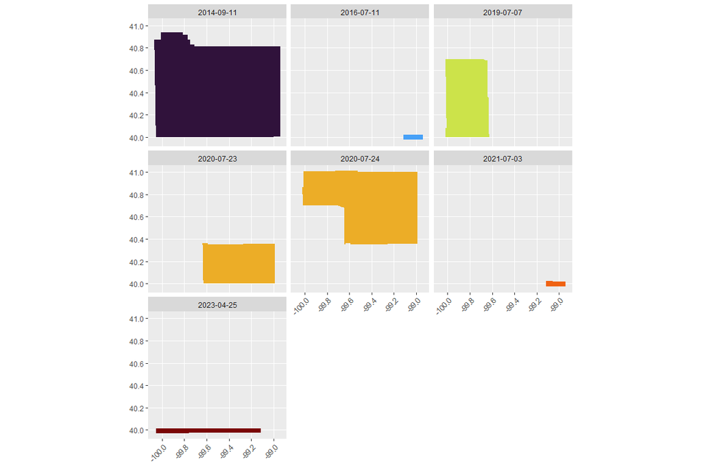

```r
# Plot the data
bbox_layer %>%
    ggplot(aes(fill = publicationDate)) + # Fill polygons according to publication date
    geom_sf(color = NA, show.legend = FALSE) +
    scale_fill_viridis_c(trans = "date", option = "turbo") + # Change color scale
    facet_wrap(~publicationDate) +
    theme(axis.text.x = element_text(angle = 45, hjust = 1))
```

## Fire data

I got a [dataset](https://data-nifc.opendata.arcgis.com/datasets/nifc::historic-perimeters-combined-2000-2018-geomac/explore?location=39.096733%2C-96.133955%2C5.57) of fire perimeter shapefiles from the National Interagency Fire Center. If you want to run this code, which I otherwise (as of now) managed to make reproducible, you’ll have to download and unzip the same dataset first. I might consider adding some subset of it to the GitHub repository to make the code totally reproducible but the unedited database is too large to do so.

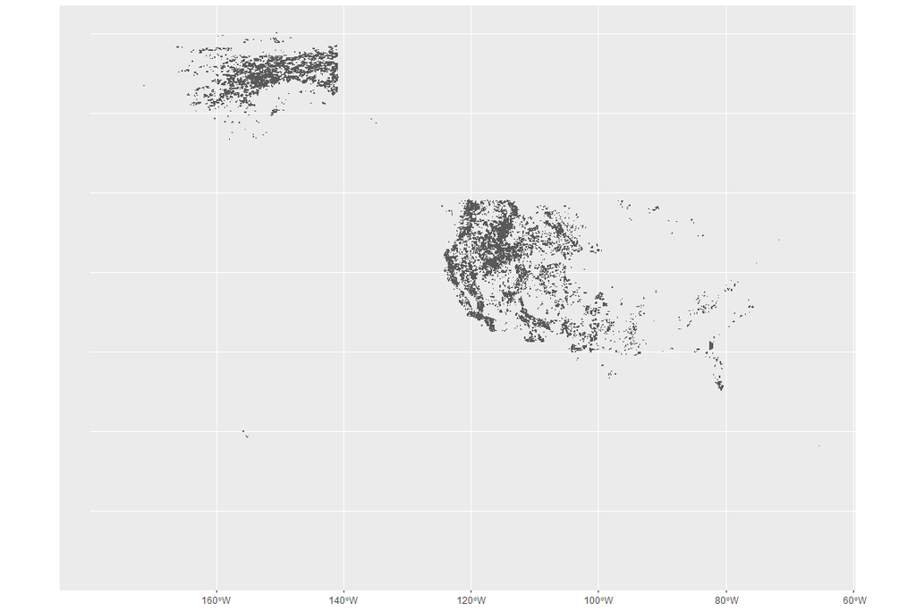

```r
fires <- st_read("./data/Historic_Perimeters_Combined_2000-2018_GeoMAC/US_HIST_FIRE_PERIMTRS_2000_2018_DD83.shp")
fires %>%
    ggplot() +
    geom_sf()
```

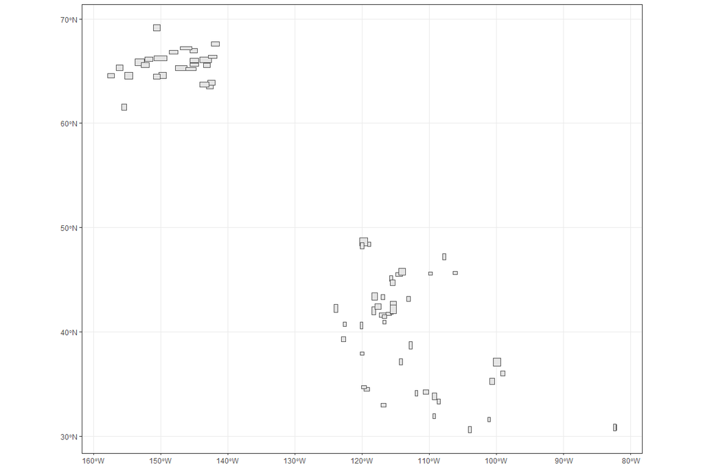

```r
bboxes <- fires %>%
    filter(gisacres > 2e5) %>%
    group_by(uniquefire) %>%
    filter(gisacres == max(gisacres)) %>%
    transmute(bbox = st_as_sfc(st_bbox(geometry)))

bboxes$bbox %>%
    ggplot() +
    geom_sf() +
    theme_bw()
```

## Next steps

- Focus on areas covered by fire perimeters
- Scale up
- Find cases where LiDAR publication dates sandwich fire perimeter dates